# ESTIMACIÓN DE MODELOS GARCH PARA LOS RENDIMIENTOS DEL SP500

Carlos Arturo Cáceres Ojeda (caceresojeda@gmail.com)

## 1. RESUMEN

En el presente artículo se muestra el proceso de estimación de diferentes modelos de la familia GARCH para los rendimientos mensuales del SP500. Específicamente, se estima un modelo *ARMA(p,q)* para la ecuación de la media de los redindimientos del SP500, y a partir de este se estiman y explican los siguientes modelos *ARCH(p), GARCH(1,1), GARCH(p,q), ARCH-M, TGARCH, EGARCH* para la ecuación de la varianza. Finalmente, se comparan los resultados y se selecciona el modelo mejor especificado.

## 2. IMPORTACIÓN DE LA SERIE DE TIEMPO: RENDIMIENTOS MENSUALES SP500

Se importa la serie de tiempo de los rendimientos mensuales del SP500. A primera vista se aprecia que la serie es estacionaria, puesto oscila alrededor del cero. Adicionalmente, en las primeras 200 observaciones de la serie de tiempo se muestra que la volatilidad es mayor que con respecto a los meses más rencientes.

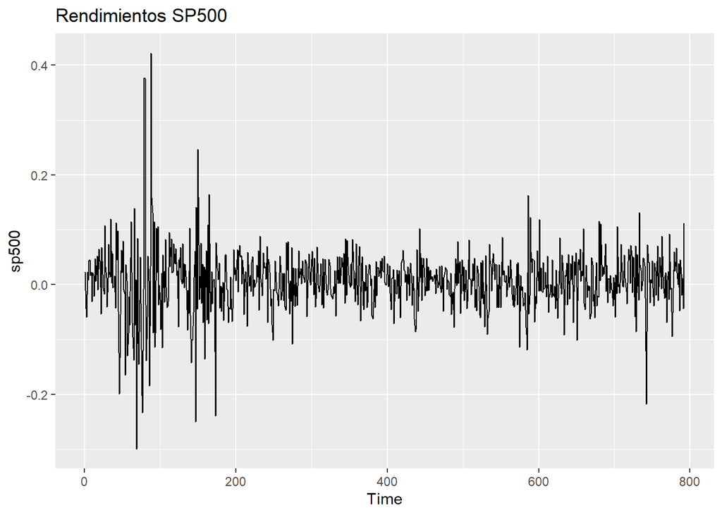

## 3. IDENTIFICACIÓN Y ESTIMACIÓN DE LA ECUACIÓN DE LA MEDIA

### A. Identificación de los ordenes AR(p) y MA(q)

Para identificar la ecuación de la media por medio de un modelo *ARMA(p,q)*, se construyen los plot de la Función de Autocorrelación Parcial PACF y de la Función de Auto Correlación Simple ACF. Mientras que el PACF nos da información sobre los $p$, es decir si hay presencia de estructuras autoregresivas (*AR*), el ACF nos da información sobre los $q$, es decir, si hay presencia estructuras de media móvil (*MA*). En este caso, los dos plot indican que el máximo **orden AR es 3**, mientras que el máximo **orden MA es 3**.

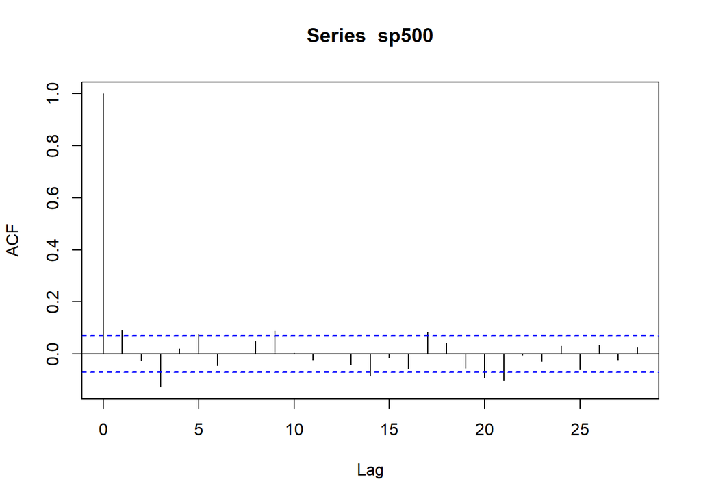

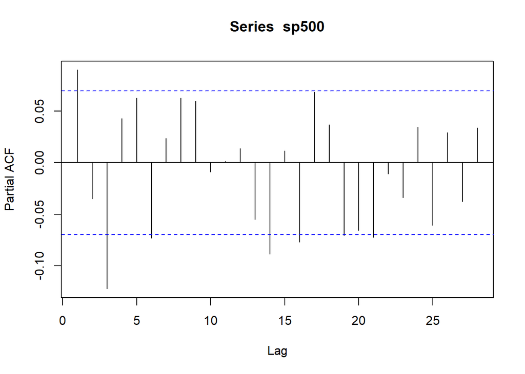

### B. Estimación de la Ecuación de la Media (Modelo ARIMA)

Para la estimación de la ecuación de la media se propone usar en primer lugar un modelo arima automático, posteriormente se reajusta para identificar el mejor modelo:

```
##
## z test of coefficients:
##
##             Estimate Std. Error z value Pr(>|z|)
## ar1       -0.1702494  0.1587912 -1.0722 0.283649
## ar2       -0.6008847  0.1151817 -5.2168 1.82e-07 ***
## ma1        0.2657245  0.1608483  1.6520 0.098531 .
## ma2        0.6261631  0.1301805  4.8100 1.51e-06 ***
## ma3       -0.0804203  0.0473898 -1.6970 0.089698 .
## intercept  0.0061580  0.0020829  2.9565 0.003112 **
## ---
## Signif. codes:  0 '***' 0.001 '**' 0.01 '*' 0.05 '.' 0.1 ' ' 1
```

```
##
## z test of coefficients:
##
##             Estimate Std. Error z value  Pr(>|z|)
## ar1       -0.3615738  0.1201389 -3.0096  0.002616 **
## ar2       -0.7183591  0.0804205 -8.9325 < 2.2e-16 ***
## ma1        0.4832025  0.1031864  4.6828  2.83e-06 ***
## ma2        0.7970222  0.0788931 10.1026 < 2.2e-16 ***
## intercept  0.0061644  0.0022354  2.7576  0.005822 **
## ---
## Signif. codes:  0 '***' 0.001 '**' 0.01 '*' 0.05 '.' 0.1 ' ' 1
```

### C. Validación de la Especificación de la Ecuación para la Media

Se observa que el mejor modelo *ARIMA* es aquel con la siguiente especificación: *ARIMA(2,0,2)*. Para verificar que está correctamente especificado, se comprueban las funciones de autocorrelación simple (*ACF*) y parcial (*PACF*) de los residuales del modelo especificado para la media, se comprueba que el modelo está correctamente especificado, puesto que los primeros rezagos de *ACF* y *PACF* no presentan autocorrelaciones significativas distintas de cero:

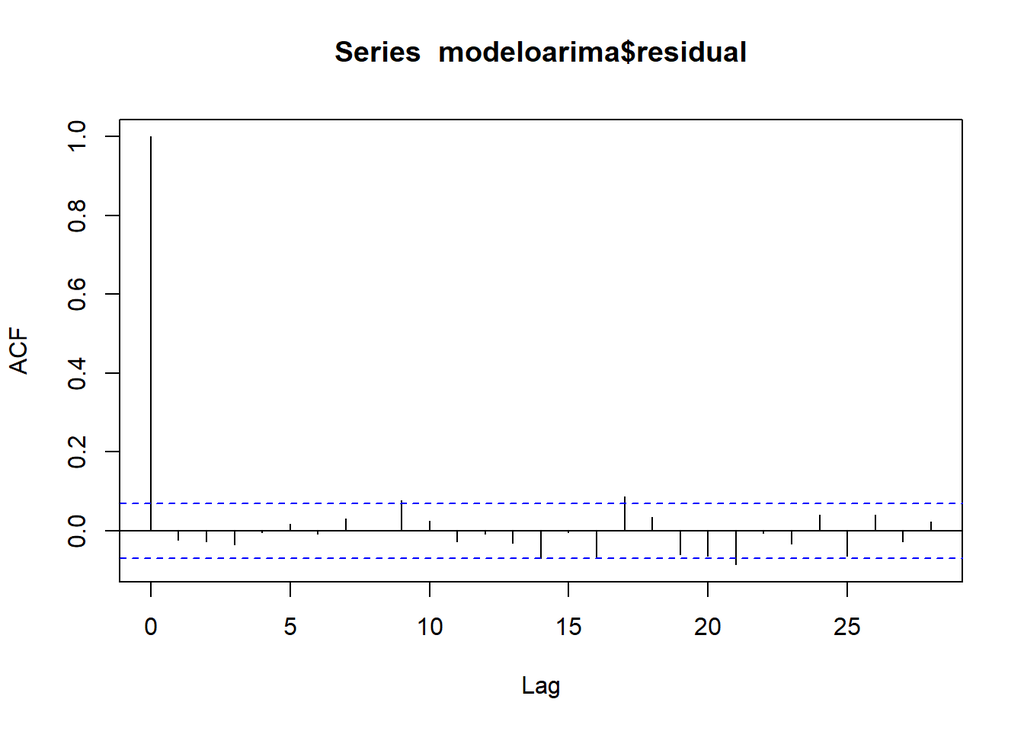

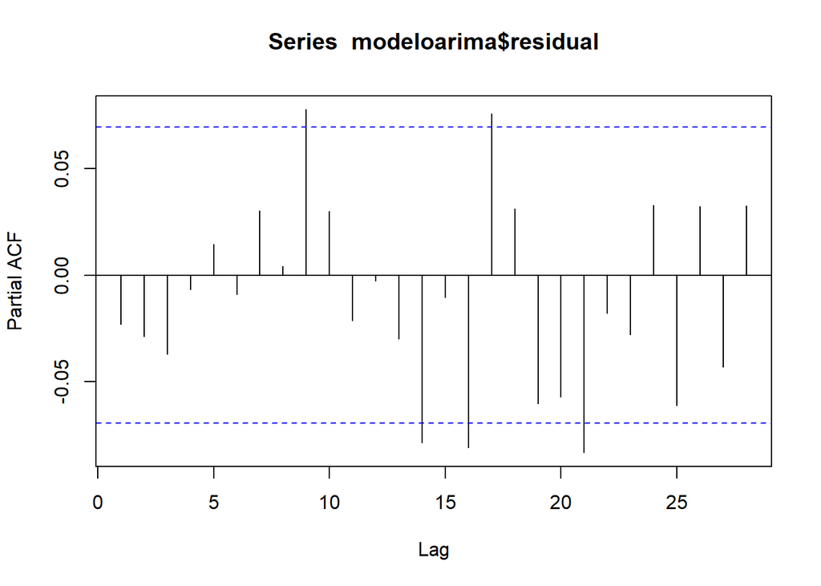

Finalmente, se tiene que la estructura del modelo estimado es la siguiente:

$R_{t}=\mu_{t}+\varepsilon_{t}$

Mientras que se tiene en cuenta el siguiente modelo *ARIMA* para la ecuación de la media:

$\mu_{t}=\psi + \phi_{1}{R_{t-1}} + \phi_{2}R_{t-2} + \theta_{1}\varepsilon_{t-1} + \theta_{2}\varepsilon_{t-2}$

## 4. IDENTIFICACIÓN DE LA ECUACIÓN DE LA VARIANZA

### A. Análisis ACF y PACF Sobre la Serie de Retornos del SP500 al Cuadrado

Para identificar la ecuación de la varianza por medio de modelos *GARCH*, se construyen los plot de la Función de Autocorrelación Parcial PACF y de la Función de Auto Correlación Simple ACF teniendo en cuenta los rendimientos del SP500 al cuadrado. Se muestran rezagos estadísticamente significativos y persistentes de los rendimientos al cuadrado, por lo cual nos da indicios que se debe especificar un modelo de la familia *GARCH* para la ecuación de la varianza.

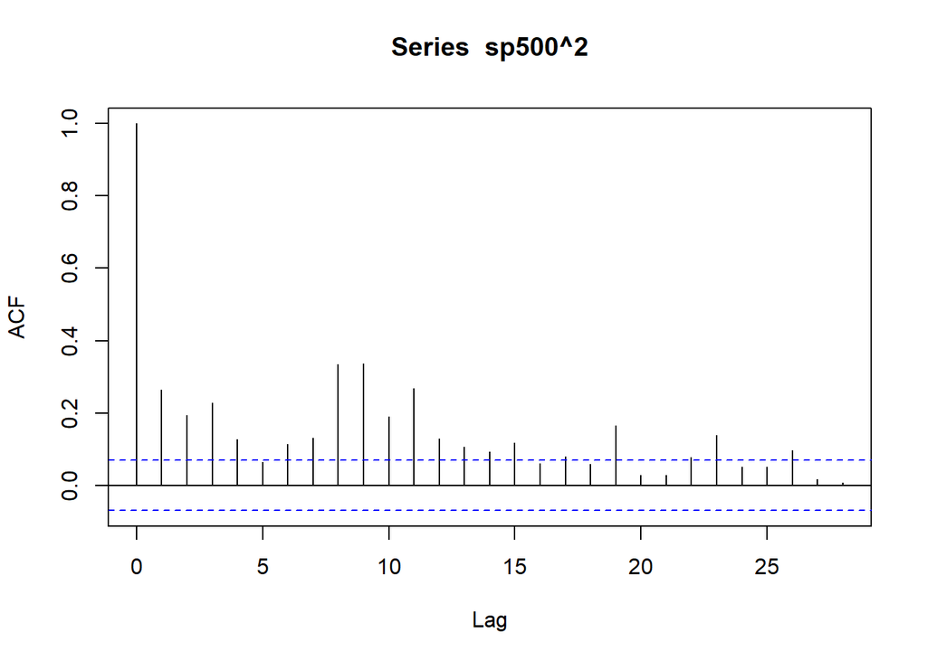

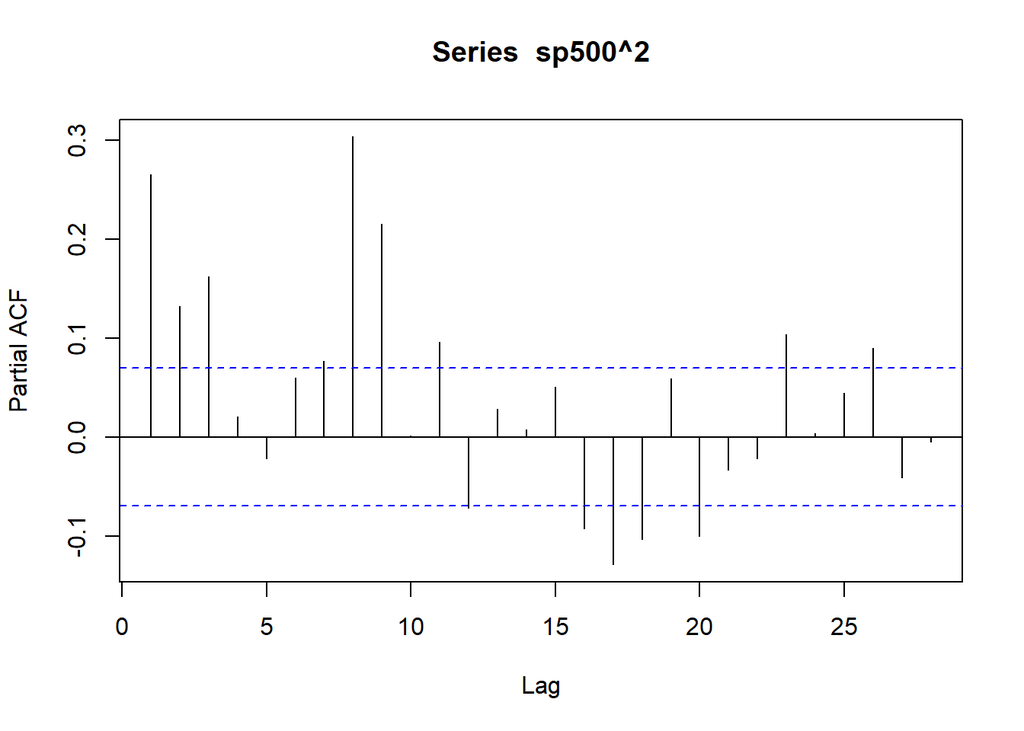

### B. Prueba de Efectos ARCH

Para la estimación de la ecuación de la varianza se realiza previamente la prueba de *Efectos ARCH* sobre los residuales del modelo de la ecuación de la media, las pruebas consisten en determinar si existe efecto de volatilidad/varianza condicional heterocedástica; específicamente, se implementan dos tipos de pruebas: **Prueba Ljung-Box** y **Prueba de Multiplicadores de Lagrange**, ambas pruebas comparten la siguiente prueba de hipótesis:

$H_{0}:\ \mathbb{no\ existe\ efecto}\ ARCH$ $H_{1}:\ \mathbb{existe\ efecto}\ ARCH$

Se muestra que en ambas pruebas se rechaza la hipótesis nula de volatilidad constante; puesto que todos los *p-value* son inferiores al $5\%$ de significancia y se concluye que existe efecto ARCH.

```
## ARCH heteroscedasticity test for residuals
## alternative: heteroscedastic
##
## Portmanteau-Q test:
##      order  PQ p.value
## [1,]     4 118       0
## [2,]     8 226       0
## [3,]    12 393       0
## [4,]    16 436       0
## [5,]    20 470       0
## [6,]    24 496       0
## Lagrange-Multiplier test:
##      order    LM  p.value
## [1,]     4 796.3 0.00e+00
## [2,]     8 365.1 0.00e+00
## [3,]    12 140.6 0.00e+00
## [4,]    16 102.7 4.00e-15
## [5,]    20  75.4 1.15e-08
## [6,]    24  56.4 1.25e-04
```

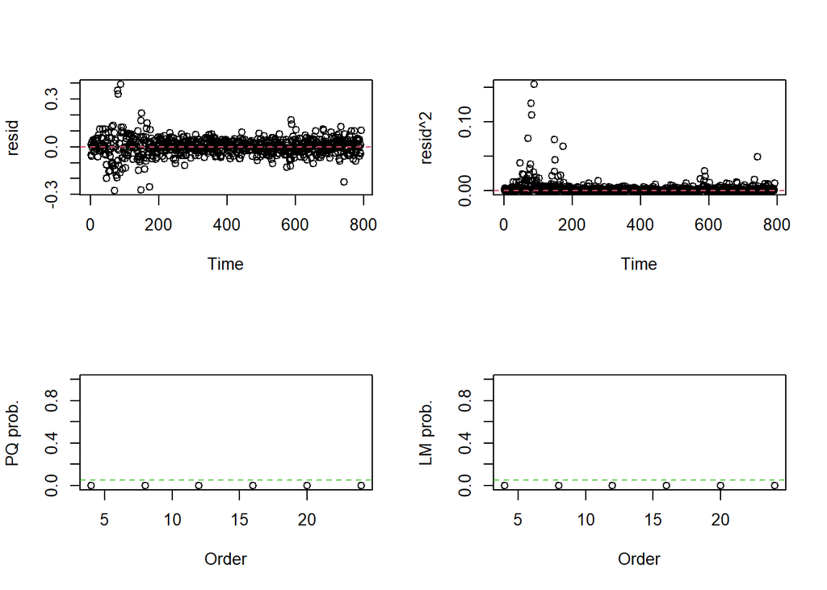

### C. Identificación de los modelos GARCH

Para corroborar el resultado de las pruebas de Efectos ARCH y también para especificar los modelos *GARCH*, se computan las funciones de autocorrelación simple (*ACF*) y parcial (*PACF*) de los residuales al cuadrado de la ecuación de la media, se comprueba la presencia de rezagos significativos y persistentes, lo cual indica que hay heterocedasticidad condicional y por lo tanto se pueden especificar diferentes modelos de la familia *GARCH*.

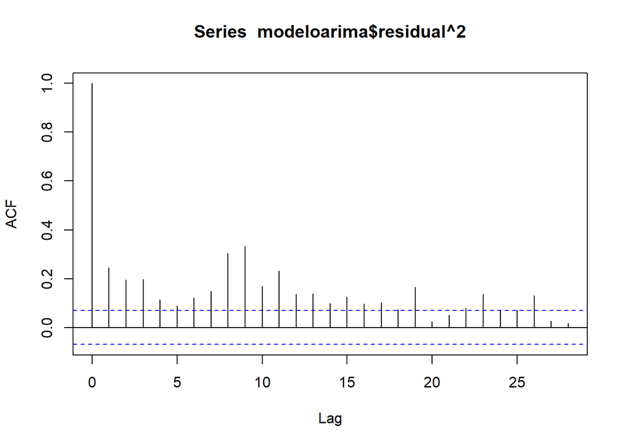

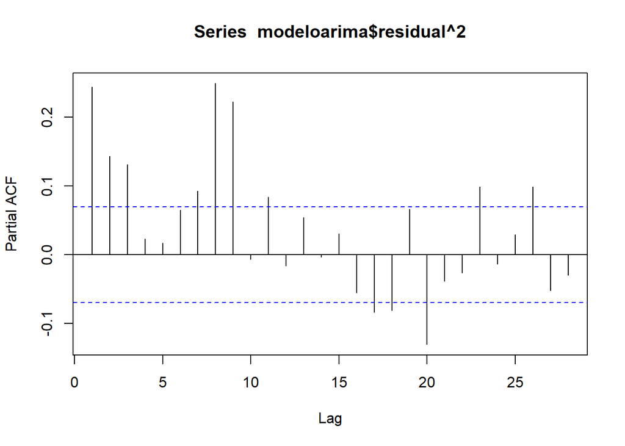

## 5. ESTIMACIÓN DE LA ECUACIÓN DE LA VARIANZA

De acuerdo con los resultados de las funciones de autocorrelación simple (*ACF*) y parcial (*PACF*) de los residuos al cuadrado de la ecuación de la media, se pueden plantear los siguientes modelos para la ecuación de la varianza:

- **ARCH(3)**
- **GARCH(1,1)**
- **GARCH(3,3)**
- **GARCH-M(1,1)**
- **TGARCH(1,1)**
- **EGARCH(1,1)**

### A. Estimación Modelo ARCH(3)

La estimación de la ecuación de la varianza para un modelo *ARCH(3)* está definido por la siguiente expresión:

$\sigma^2_{t}=\omega\ +\ \alpha_{1}\varepsilon^2_{t-1} +\ \alpha_{2}\varepsilon^2_{t-2} +\ \alpha_{3}\varepsilon^2_{t-3}$

Donde,

$\varepsilon_{t}=\sigma_{t}a_{t},\ a_{t}\sim{iid}\ N(0,1),\ \sigma_{t}\ \mathbb{y}\ a_{t}\ \mathbb{independientes}$

Los resultados de la estimación tanto de la ecuación de la media (*ARIMA(2,0,2)*) como de la varianza (*ARCH(3)*) son los siguientes:

```
##
## *---------------------------------*
## *          GARCH Model Fit        *
## *---------------------------------*
##
## Conditional Variance Dynamics
## -----------------------------------
## GARCH Model  : sGARCH(3,0)
## Mean Model   : ARFIMA(2,0,2)
## Distribution : norm
##
## Optimal Parameters
## ------------------------------------
##         Estimate  Std. Error   t value Pr(>|t|)
## mu      0.007102    0.001276    5.5652 0.000000
## ar1    -1.900640    0.004226 -449.7227 0.000000
## ar2    -0.930420    0.003263 -285.1352 0.000000
## ma1     1.932900    0.000207 9348.5847 0.000000
## ma2     0.956692    0.001303  734.3174 0.000000
## omega   0.001217    0.000138    8.8069 0.000000
## alpha1  0.101670    0.045788    2.2204 0.026389
## alpha2  0.229990    0.052870    4.3501 0.000014
## alpha3  0.337440    0.077258    4.3677 0.000013
##
## Robust Standard Errors:
##         Estimate  Std. Error   t value Pr(>|t|)
## mu      0.007102    0.001641    4.3289 0.000015
## ar1    -1.900640    0.007050 -269.5940 0.000000
## ar2    -0.930420    0.006142 -151.4881 0.000000
## ma1     1.932900    0.000349 5541.4808 0.000000
## ma2     0.956692    0.002024  472.6551 0.000000
## omega   0.001217    0.000219    5.5552 0.000000
## alpha1  0.101670    0.058235    1.7459 0.080833
## alpha2  0.229990    0.101843    2.2583 0.023928
## alpha3  0.337440    0.121584    2.7754 0.005514
##
## LogLikelihood : 1244.961
##
## Information Criteria
## ------------------------------------
```

[output cut: 52 more lines]

```
## Negative Sign Bias  0.3134 0.75406
## Positive Sign Bias  0.1320 0.89499
## Joint Effect        8.6123 0.03492  **
##
##
## Adjusted Pearson Goodness-of-Fit Test:
## ------------------------------------
##   group statistic p-value(g-1)
## 1    20     37.85     0.006204
## 2    30     54.97     0.002498
## 3    40     71.33     0.001201
## 4    50     62.55     0.092537
##
##
## Elapsed time : 2.491013
```

De acuerdo con el resultado de la salida anterior, se muestra que a pesar que el modelo No Rechaza la Hipótesis Nula de la prueba de Efectos ARCH, al realizar el análisis de las funciones de autocorrelación simple (*ACF*) y parcial (*PACF*) de los residuales al cuadrado del modelo, se muestra que sigue presentando rezagos significativos; además, se Rechaza la Hipótesis Nula de No Correlación Serial de los residuales; es decir, el modelo no está lo suficientemente especificado.

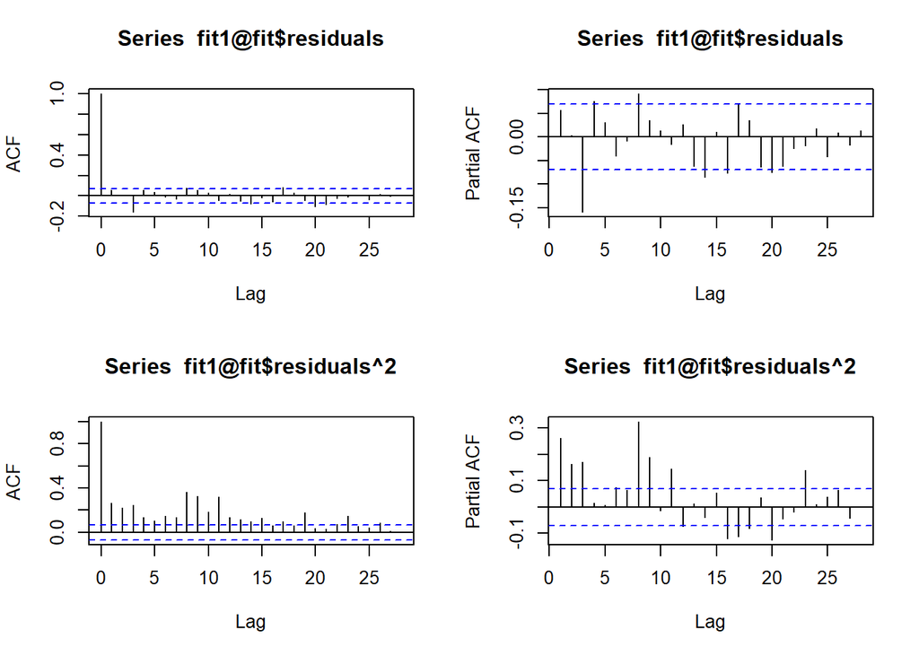

### B. Estimación Modelo GARCH(1,1)

La estimación de la ecuación de la varianza para un modelo *GARCH(1,1)* está definido por la siguiente expresión:

$\sigma^2_{t}=\omega\ +\ \alpha_{1}\varepsilon^2_{t-1} +\ \beta_{1}\sigma^2_{t-1}$

Donde,

$\varepsilon_{t}=\sigma_{t}a_{t},\ a_{t}\sim{iid}\ N(0,1),\ \sigma_{t}\ \mathbb{y}\ a_{t}\ \mathbb{independientes}$

Los resultados de la estimación tanto de la ecuación de la media (*ARIMA(2,0,2)*) como de la varianza (*GARCH(1,1)*) son los siguientes:

```
##
## *---------------------------------*
## *          GARCH Model Fit        *
## *---------------------------------*
##
## Conditional Variance Dynamics
## -----------------------------------
## GARCH Model  : sGARCH(1,1)
## Mean Model   : ARFIMA(2,0,2)
## Distribution : norm
##
## Optimal Parameters
## ------------------------------------
##         Estimate  Std. Error   t value Pr(>|t|)
## mu      0.007407    0.001548    4.7858 0.000002
## ar1    -0.349565    0.006366  -54.9071 0.000000
## ar2    -0.974801    0.001143 -852.7788 0.000000
## ma1     0.367088    0.001561  235.1963 0.000000
## ma2     0.997103    0.000209 4779.0935 0.000000
## omega   0.000076    0.000028    2.7290 0.006353
## alpha1  0.120267    0.022266    5.4014 0.000000
## beta1   0.857375    0.022218   38.5886 0.000000
##
## Robust Standard Errors:
##         Estimate  Std. Error   t value Pr(>|t|)
## mu      0.007407    0.001743    4.2501 0.000021
## ar1    -0.349565    0.006509  -53.7018 0.000000
## ar2    -0.974801    0.003691 -264.0829 0.000000
## ma1     0.367088    0.001442  254.5397 0.000000
## ma2     0.997103    0.000247 4040.4024 0.000000
## omega   0.000076    0.000034    2.2071 0.027307
## alpha1  0.120267    0.028107    4.2789 0.000019
## beta1   0.857375    0.027029   31.7207 0.000000
##
## LogLikelihood : 1276.472
##
## Information Criteria
## ------------------------------------
##
## Akaike       -3.2032
```

[output cut: 49 more lines]

```
## Negative Sign Bias  0.7822 0.4343476
## Positive Sign Bias  0.3483 0.7277051
## Joint Effect       18.4802 0.0003501 ***
##
##
## Adjusted Pearson Goodness-of-Fit Test:
## ------------------------------------
##   group statistic p-value(g-1)
## 1    20     33.91      0.01884
## 2    30     42.92      0.04627
## 3    40     44.97      0.23610
## 4    50     62.17      0.09806
##
##
## Elapsed time : 0.777987
```

De acuerdo con el resultado de la salida anterior, se muestra que a pesar que el modelo No Rechaza la Hipótesis Nula de la prueba de Efectos ARCH, al realizar el análisis de las funciones de autocorrelación simple (*ACF*) y parcial (*PACF*) de los residuales al cuadrado del modelo, se muestra que sigue presentando rezagos significativos; además, NO se Rechaza la Hipótesis Nula de No Correlación Serial de los residuales; sin embargo, el modelo no está lo suficientemente especificado.

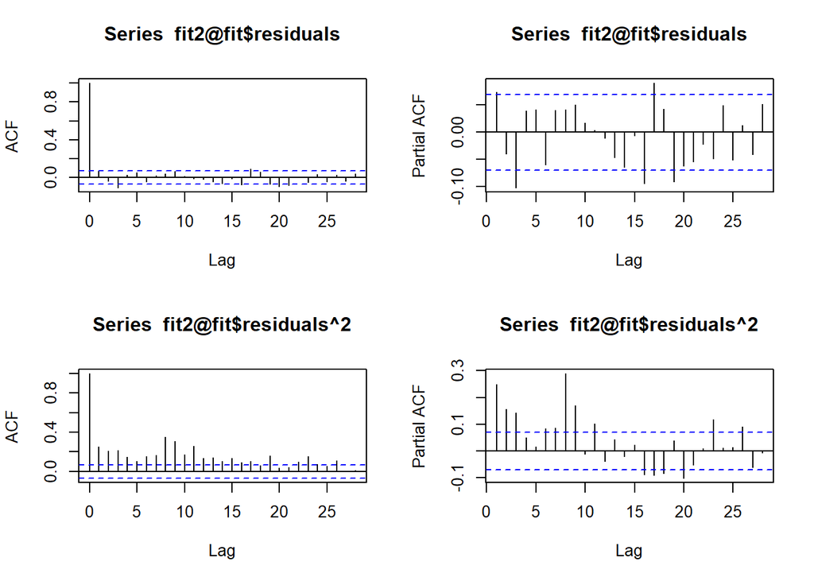

### C. Estimación Modelo GARCH(3,3)

$\sigma^2_{t}=\omega\ +\ \alpha_{1}\varepsilon^2_{t-1} +\ \alpha_{2}\varepsilon^2_{t-2} +\ \alpha_{3}\varepsilon^2_{t-3} +\ \beta_{1}\sigma^2_{t-1} +\ \beta_{2}\sigma^2_{t-2} +\ \beta_{3}\sigma^2_{t-3}$

Donde,

$\varepsilon_{t}=\sigma_{t}a_{t},\ a_{t}\sim{iid}\ N(0,1),\ \sigma_{t}\ \mathbb{y}\ a_{t}\ \mathbb{independientes}$

Los resultados de la estimación tanto de la ecuación de la media (*ARIMA(2,0,2)*) como de la varianza (*GARCH(3,3)*) son los siguientes:

```
##
## *---------------------------------*
## *          GARCH Model Fit        *
## *---------------------------------*
##
## Conditional Variance Dynamics
## -----------------------------------
## GARCH Model  : sGARCH(3,3)
## Mean Model   : ARFIMA(2,0,2)
## Distribution : norm
##
## Optimal Parameters
## ------------------------------------
##         Estimate  Std. Error  t value Pr(>|t|)
## mu      0.006959    0.001567   4.4402 0.000009
## ar1    -0.242498    0.086629  -2.7993 0.005122
## ar2    -0.877484    0.070214 -12.4973 0.000000
## ma1     0.291943    0.088890   3.2843 0.001022
## ma2     0.878849    0.066910  13.1348 0.000000
## omega   0.000219    0.000073   3.0025 0.002677
## alpha1  0.055543    0.027125   2.0477 0.040593
## alpha2  0.127665    0.036902   3.4596 0.000541
## alpha3  0.184938    0.043050   4.2959 0.000017
## beta1   0.000000          NA       NA       NA
## beta2   0.000000          NA       NA       NA
## beta3   0.574808    0.050279  11.4323 0.000000
##
## Robust Standard Errors:
##         Estimate  Std. Error  t value Pr(>|t|)
## mu      0.006959    0.001793   3.8807 0.000104
## ar1    -0.242498    0.083701  -2.8972 0.003765
## ar2    -0.877484    0.067859 -12.9309 0.000000
## ma1     0.291943    0.089996   3.2440 0.001179
## ma2     0.878849    0.059947  14.6605 0.000000
## omega   0.000219    0.000091   2.4044 0.016200
## alpha1  0.055543    0.032273   1.7210 0.085243
## alpha2  0.127665    0.051018   2.5024 0.012337
## alpha3  0.184938    0.059018   3.1336 0.001727
## beta1   0.000000          NA       NA       NA
## beta2   0.000000          NA       NA       NA
```

[output cut: 59 more lines]

```
## Negative Sign Bias  0.14837 0.8820903
## Positive Sign Bias  0.04056 0.9676549
## Joint Effect       18.85982 0.0002923 ***
##
##
## Adjusted Pearson Goodness-of-Fit Test:
## ------------------------------------
##   group statistic p-value(g-1)
## 1    20     29.82     0.054158
## 2    30     51.03     0.006978
## 3    40     56.69     0.033311
## 4    50     65.07     0.061854
##
##
## Elapsed time : 1.326003
```

De acuerdo con el resultado de la salida anterior, se muestra que a pesar que el modelo No Rechaza la Hipótesis Nula de la prueba de Efectos ARCH, al realizar el análisis de las funciones de autocorrelación simple (*ACF*) y parcial (*PACF*) de los residuales al cuadrado del modelo, se muestra que sigue presentando rezagos significativos; además, NO se Rechaza la Hipótesis Nula de No Correlación Serial de los residuales; sin embargo, el modelo no está lo suficientemente especificado.

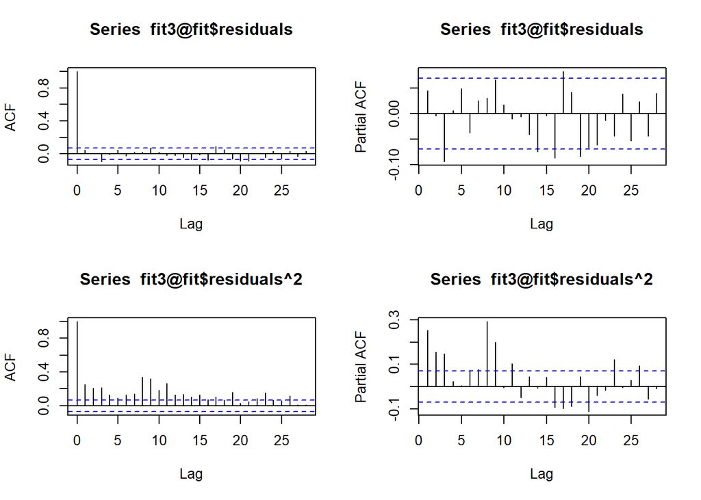

### D. Estimación Modelo GARCH-M(1,1)

De acuerdo con el tipo de especificación de este modelo, se sabe que la ecuación de la media es distinta a la planteada hasta el momento, toda vez que el efecto de la volatilidad/varianza condicional afecta directamente la ecuación de la media. De esta manera, la estimación del modelo para la ecuación de la media *ARIMA(2,0,2) + GARCH-M(1,1)* está definido por las siguientes expresiones:

$R_{t}\ =\ \mu_{t}\ + \varepsilon_{t}$

Donde,

$\mu_{t}=\zeta + \eta\cdot\sigma^2_{t}$

$\zeta=\psi + \phi_{1}{R_{t-1}} + \phi_{2}R_{t-2} + \theta_{1}\varepsilon_{t-1} + \theta_{2}\varepsilon_{t-2}$

$\sigma^2_{t}=\omega\ +\ \alpha_{1}\varepsilon^2_{t-1} +\ \beta_{1}\sigma^2_{t-1}$

$\varepsilon_{t}\mid\Omega_{t-1}\ \sim\ N(0,\sigma^2_{t})$

Los resultados de la estimación para este modelo (*ARIMA(2,0,2) + GARCH-M(1,1)*) son los siguientes:

```
##
## *---------------------------------*
## *          GARCH Model Fit        *
## *---------------------------------*
##
## Conditional Variance Dynamics
## -----------------------------------
## GARCH Model  : sGARCH(1,1)
## Mean Model   : ARFIMA(2,0,2)
## Distribution : norm
##
## Optimal Parameters
## ------------------------------------
##         Estimate  Std. Error  t value Pr(>|t|)
## mu      0.005555    0.002414   2.3009 0.021398
## ar1    -0.224514    0.077269  -2.9056 0.003665
## ar2    -0.894549    0.064407 -13.8891 0.000000
## ma1     0.271163    0.080430   3.3714 0.000748
## ma2     0.886846    0.067039  13.2287 0.000000
## archm   0.986045    0.922693   1.0687 0.285223
## omega   0.000082    0.000029   2.8558 0.004293
## alpha1  0.121737    0.022228   5.4767 0.000000
## beta1   0.853409    0.022336  38.2073 0.000000
##
## Robust Standard Errors:
##         Estimate  Std. Error  t value Pr(>|t|)
## mu      0.005555    0.002513   2.2110 0.027034
## ar1    -0.224514    0.074659  -3.0072 0.002637
## ar2    -0.894549    0.065840 -13.5868 0.000000
## ma1     0.271163    0.076937   3.5245 0.000424
## ma2     0.886846    0.066250  13.3864 0.000000
## archm   0.986045    0.936250   1.0532 0.292256
## omega   0.000082    0.000035   2.3840 0.017127
## alpha1  0.121737    0.027236   4.4697 0.000008
## beta1   0.853409    0.026976  31.6362 0.000000
##
## LogLikelihood : 1273.924
##
## Information Criteria
## ------------------------------------
```

[output cut: 52 more lines]

```
## Negative Sign Bias  0.7872 0.43140
## Positive Sign Bias  0.8214 0.41167
## Joint Effect       16.1431 0.00106 ***
##
##
## Adjusted Pearson Goodness-of-Fit Test:
## ------------------------------------
##   group statistic p-value(g-1)
## 1    20     31.43      0.03615
## 2    30     41.18      0.06639
## 3    40     40.93      0.38582
## 4    50     62.17      0.09806
##
##
## Elapsed time : 2.040018
```

De acuerdo con el resultado de la salida anterior, se muestra que a pesar que el modelo No Rechaza la Hipótesis Nula de la prueba de Efectos ARCH, al realizar el análisis de las funciones de autocorrelación simple (*ACF*) y parcial (*PACF*) de los residuales al cuadrado del modelo, se muestra que sigue presentando rezagos significativos; además, NO se Rechaza la Hipótesis Nula de No Correlación Serial de los residuales; sin embargo, el modelo no está lo suficientemente especificado.

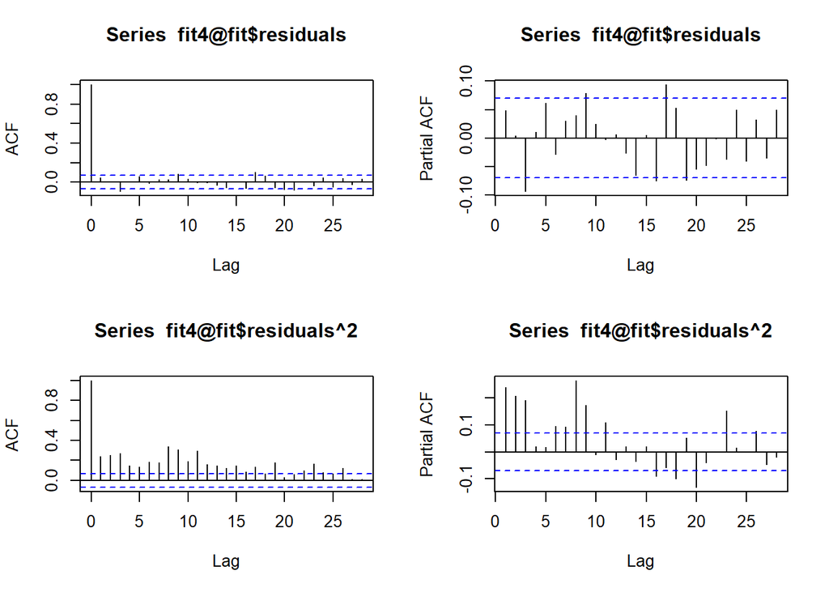

### E. Estimación Modelo TGARCH(1,1)

La estimación de la ecuación de la varianza para un modelo *TGARCH(1,1)* está definido por la siguiente expresión:

$\sigma^2_{t}=\omega\ +\ \alpha_{1}\varepsilon^2_{t-1} +\ \eta\ d_{t-1}\varepsilon^2_{t-1} +\ \beta_{1}\sigma^2_{t-1}$

Donde,

$\varepsilon_{t}=\sigma_{t}a_{t},\ a_{t}\sim{iid}\ N(0,1),\ \sigma_{t}\ \mathbb{y}\ a_{t}\ \mathbb{independientes}$

$d_{t-1}=\left\lbrace\begin{array}{c} 1,~\mathbb{si}\ \varepsilon_{t-1}<0\\0, \mathbb{si}\ \varepsilon_{t-1}\geq0 \end{array}\right.$

La principal característica de este tipo de modelo es que permite dar más peso a los choques de retornos negativos sobre los positivos; puesto que asume que rendimientos negativos de activos financieros son más volátiles.

Los resultados de la estimación tanto de la ecuación de la media (*ARIMA(2,0,2)*) como de la varianza (*TGARCH(1,1)*) son los siguientes:

```
##
## *---------------------------------*
## *          GARCH Model Fit        *
## *---------------------------------*
##
## Conditional Variance Dynamics
## -----------------------------------
## GARCH Model  : fGARCH(1,1)
## fGARCH Sub-Model : TGARCH
## Mean Model   : ARFIMA(2,0,2)
## Distribution : norm
##
## Optimal Parameters
## ------------------------------------
##         Estimate  Std. Error  t value Pr(>|t|)
## mu      0.006741    0.001600   4.2122 0.000025
## ar1    -0.268098    0.032396  -8.2757 0.000000
## ar2    -0.904807    0.024858 -36.3986 0.000000
## ma1     0.310656    0.029907  10.3873 0.000000
## ma2     0.909175    0.025256  35.9983 0.000000
## omega   0.001908    0.000645   2.9573 0.003104
## alpha1  0.124595    0.019464   6.4012 0.000000
## beta1   0.867342    0.020111  43.1285 0.000000
## eta11   0.335921    0.124933   2.6888 0.007171
##
## Robust Standard Errors:
##         Estimate  Std. Error  t value Pr(>|t|)
## mu      0.006741    0.001747   3.8583 0.000114
## ar1    -0.268098    0.019893 -13.4773 0.000000
## ar2    -0.904807    0.011963 -75.6322 0.000000
## ma1     0.310656    0.015495  20.0491 0.000000
## ma2     0.909175    0.014386  63.1973 0.000000
## omega   0.001908    0.000785   2.4297 0.015111
## alpha1  0.124595    0.023863   5.2213 0.000000
## beta1   0.867342    0.025309  34.2703 0.000000
## eta11   0.335921    0.170552   1.9696 0.048883
##
## LogLikelihood : 1279.372
##
## Information Criteria
```

[output cut: 53 more lines]

```
## Negative Sign Bias   1.273 0.203236
## Positive Sign Bias   0.191 0.848560
## Joint Effect        12.693 0.005350 ***
##
##
## Adjusted Pearson Goodness-of-Fit Test:
## ------------------------------------
##   group statistic p-value(g-1)
## 1    20     23.25      0.22640
## 2    30     42.09      0.05511
## 3    40     39.52      0.44687
## 4    50     52.70      0.33307
##
##
## Elapsed time : 3.118975
```

De acuerdo con el resultado de la salida anterior, se muestra que a pesar que el modelo No Rechaza la Hipótesis Nula de la prueba de Efectos ARCH, al realizar el análisis de las funciones de autocorrelación simple (*ACF*) y parcial (*PACF*) de los residuales al cuadrado del modelo, se muestra que sigue presentando rezagos significativos; además, NO se Rechaza la Hipótesis Nula de No Correlación Serial de los residuales; sin embargo, el modelo no está lo suficientemente especificado.

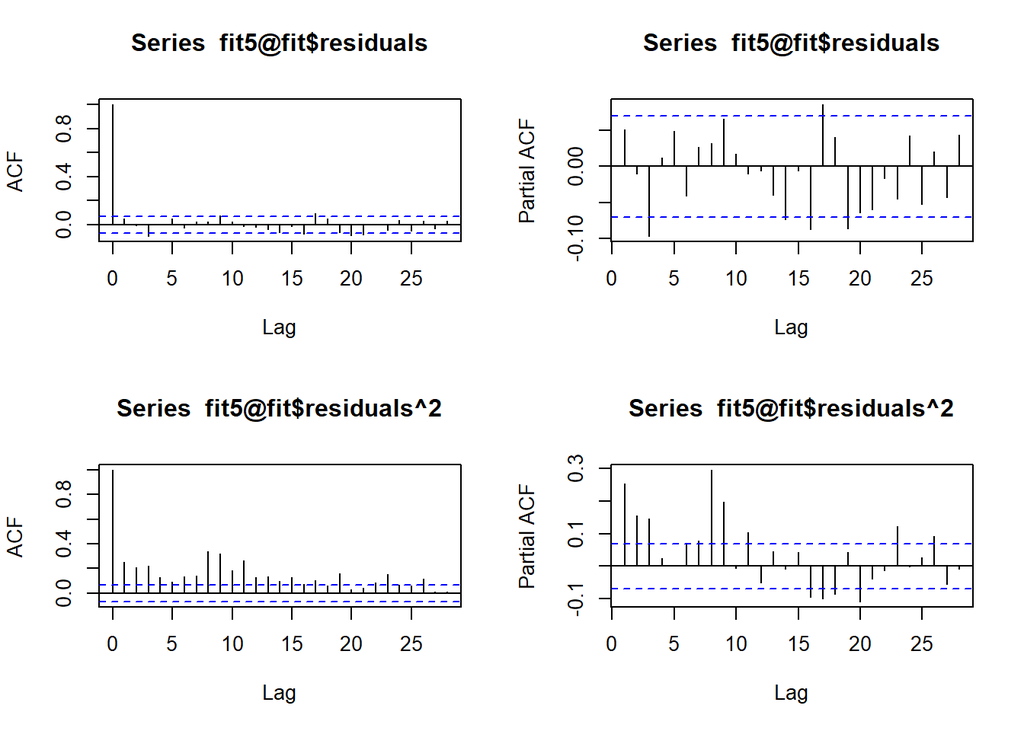

### F. Estimación Modelo EGARCH(1,1)

La estimación de la ecuación de la varianza para un modelo *EGARCH(1,1)* está definido por la siguiente expresión:

$\mathbb{log}(\sigma^2_{t})=\omega\ + \alpha_{1}|\frac{\varepsilon_{t-1}}{\sigma_{t-1}}| + \ \gamma\ \frac{\varepsilon_{t-1}}{\sigma_{t-1}}\ +\ \beta_{1}\mathbb{log}(\sigma^2_{t-1})$

Donde,

$\varepsilon_{t}=\sigma_{t}a_{t},\ a_{t}\sim{iid}\ N(0,1),\ \sigma_{t}\ \mathbb{y}\ a_{t}\ \mathbb{independientes}$

$\sigma^2_{t}=(\sigma^2_{t-1})^{\beta_{1}}\ \mathbb{exp}[\omega\ + \alpha_{1}|\frac{\varepsilon_{t-1}}{\sigma_{t-1}}| + \ \gamma\ \frac{\varepsilon_{t-1}}{\sigma_{t-1}}]$

La principal característica de este tipo de modelo, similar al modelo *TGARCH(1,1)*, es que permite dar más peso a los choques de retornos negativos sobre los positivos; puesto que asume que rendimientos negativos de activos financieros son más volátiles, para recoger la asimetría presentada en los retornos financieros positivos vs los negativos, el modelo asume que la volatilidad condicional tiene un comportamiento exponencial en el que choques negativos en los retornos financieros ocasiona una volatilidad mayor con respecto a los choques positivos, esto se debe a que:

- Si $\mathbb{\varepsilon_{t-1}}>0$ entonces $\mathbb{log}(\sigma^2_{t})=\omega\ + (\gamma\ +\ \alpha_{1})\frac{\varepsilon_{t-1}}{\sigma_{t-1}}\ +\ \beta_{1}\mathbb{log}(\sigma^2_{t-1})$
- Si $\mathbb{\varepsilon_{t-1}}<0$ entonces $\mathbb{log}(\sigma^2_{t})=\omega\ + (\gamma\ -\ \alpha_{1})\frac{\varepsilon_{t-1}}{\sigma_{t-1}}\ +\ \beta_{1}\mathbb{log}(\sigma^2_{t-1})$

Es decir, los coeficientes $(\gamma\ +\ \alpha_{1})$ y $(\gamma\ -\ \alpha_{1})$ determinan la asimetría de los choques positivos y negativos de los retornos de las series financieras.

Los resultados de la estimación tanto de la ecuación de la media (*ARIMA(2,0,2)*) como de la varianza (*EGARCH(1,1)*) son los siguientes:

```
##
## *---------------------------------*
## *          GARCH Model Fit        *
## *---------------------------------*
##
## Conditional Variance Dynamics
## -----------------------------------
## GARCH Model  : eGARCH(1,1)
## Mean Model   : ARFIMA(2,0,2)
## Distribution : norm
##
## Optimal Parameters
## ------------------------------------
##         Estimate  Std. Error  t value Pr(>|t|)
## mu      0.006864    0.001361   5.0427 0.000000
## ar1    -0.269014    0.018338 -14.6701 0.000000
## ar2    -0.902221    0.025836 -34.9216 0.000000
## ma1     0.311423    0.018091  17.2139 0.000000
## ma2     0.906124    0.024713  36.6659 0.000000
## omega  -0.164175    0.057502  -2.8551 0.004302
## alpha1 -0.057362    0.022910  -2.5038 0.012286
## beta1   0.971634    0.009452 102.7946 0.000000
## gamma1  0.229475    0.034718   6.6098 0.000000
##
## Robust Standard Errors:
##         Estimate  Std. Error  t value Pr(>|t|)
## mu      0.006864    0.001283   5.3505 0.000000
## ar1    -0.269014    0.007414 -36.2828 0.000000
## ar2    -0.902221    0.012445 -72.4956 0.000000
## ma1     0.311423    0.006874  45.3029 0.000000
## ma2     0.906124    0.012480  72.6088 0.000000
## omega  -0.164175    0.071755  -2.2880 0.022139
## alpha1 -0.057362    0.031117  -1.8434 0.065269
## beta1   0.971634    0.011311  85.9018 0.000000
## gamma1  0.229475    0.043414   5.2858 0.000000
##
## LogLikelihood : 1275.91
##
## Information Criteria
## ------------------------------------
```

[output cut: 52 more lines]

```
## Negative Sign Bias  1.21120 0.226181
## Positive Sign Bias  0.05827 0.953548
## Joint Effect       13.89368 0.003053 ***
##
##
## Adjusted Pearson Goodness-of-Fit Test:
## ------------------------------------
##   group statistic p-value(g-1)
## 1    20     24.72      0.17006
## 2    30     42.47      0.05092
## 3    40     41.74      0.35267
## 4    50     53.20      0.31567
##
##
## Elapsed time : 1.229013
```

De acuerdo con el resultado de la salida anterior, se muestra que a pesar que el modelo No Rechaza la Hipótesis Nula de la prueba de Efectos ARCH, al realizar el análisis de las funciones de autocorrelación simple (*ACF*) y parcial (*PACF*) de los residuales al cuadrado del modelo, se muestra que sigue presentando rezagos significativos; además, NO se Rechaza la Hipótesis Nula de No Correlación Serial de los residuales; sin embargo, el modelo no está lo suficientemente especificado.

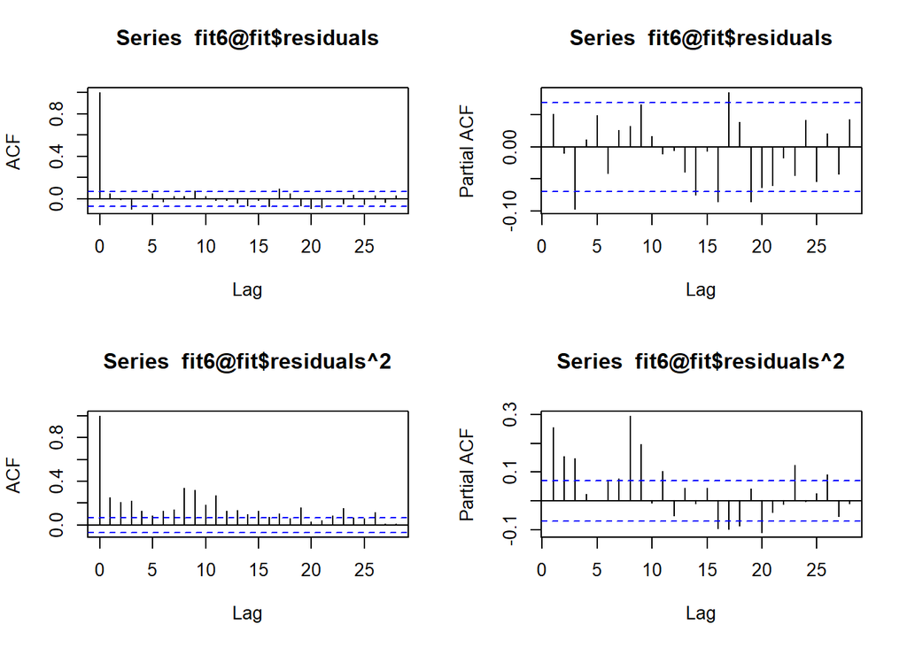

## 6. SELECCIÓN DEL MEJOR MODELO ARIMA + GARCH

De acuerdo con los resultados obtenidos de las estimaciones para la ecuación de la media y de la varianza condicional, se utilizarán los criterios AIC y BIC para seleccionar el mejor mejor, cabe mencionar que como ya se expuso, todos los modelos estimados para la varianza condicional no está lo suficientemente especificados toda vez que los residuales al cuadrado de cada modelo presentan estructuras autocorrelación; sin embargo, las pruebas de Ljunj-Box y Multiplicadores de Lagrange, al igual que de efectos ARCH son favorables y podemos optar por seleccionar el mejor modelo estimado.

| **Modelo** | **AIC** | **BIC** |
| --- | --- | --- |
| **ARCH(3)** | -3.1211128 | -3.0679927 |
| **GARCH(1,1)** | -3.2032122 | **-3.1559944** |
| **GARCH(3,3)** | -3.2056725 | -3.1466503 |
| **GARCH-M(1,1)** | -3.1942522 | -3.1411322 |
| **TGARCH(1,1)** | **-3.20801** | -3.15489 |
| **EGARCH(1,1)** | -3.1992674 | -3.1461474 |

La tabla anterior indica que el mejor modelo de acuerdo al criterio del *AIC* es el **TGARCH(1,1)**; mientras que según el criterio del BIC es el **GARCH(1,1)**; puesto que corresponden a los menores valores de **AIC** y **BIC** en comparación con los demás modelos.